# Your Digest for Wednesday, Apr 24, 2024 11:59 PM

Kerr's sign:

- Shoulder tip pain caused by diaphrgmatic irritation with splenic laceration.
- ⭐Congenital adrenal hyperplasia results from #autosomal-Recessive deficiency of **21-alpha hydroxylase enzyme**. Deficiency diverts synthesis towards the androgenic pathway and decreases mineralocorticoid and glucocorticoid function.
- ⭐increased testoterone -> virilization
- ⭐Impaired aldosterone -> salt wasting.
- ⭐females -> ambiguous genitalia
- ⭐Males -> salt wasting crisis will be the presenting feature at < 10 days old.
- Holmes-adie syndrome is associated with migraine.
  - There is partial or total loss of neurons of the *ciliary ganglion*. (and also loss of some spinal neurons)

# Postpartum cardiomyopathy

- Occurs from 1 month **before** to **5 months after** delivery.
- PPCM is diagnosed when no other cause is identified.
- Risk factors:
  - Advanced maternal age
  - High parity, high gravidity, Twin pregnancy
  - Hypertension
  - Cocaine use
  - Poverty  
    [Source](https://www.ncbi.nlm.nih.gov/books/NBK534770/)
- **Daily recurring fever or two fever spikes per day**.
- Arthralgia or **arthritis** - mild transient oligoarticular arthritis but can progress to severe arthritis.
- Investigation: **Leukocytosis**, ⬆ESR, ⬆ CRP, **⬆ Ferritin**, **⬆ hepatic aminotransferase**.

Squamous cell CA

Basal Cell carcinoma

Maligant melanoma

Chronic non healing ulcers or firm pink rapidly growing size

Pearly, flesh coloured lesion with rolled up edges, central depression and telangiectasia. Occurs in **sun exposed areas**  
AKA **Rodent ulcer**

ABCDE lesions

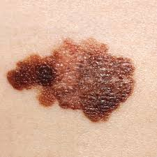

Rapidly growing

Slow growing. Arises from **keratinocytes**.  
"only rarely a threat to life"

The **most dangerous skin cancer**; use ABCDE as warning signs. Arises from **melanocytes** which are neural crest derivatives

Metastasis is uncommon. (upto 5%)

**Metastasis** common. (Nodes and distant). 5 year survival for nodal mestastasis is *only 10%.*

RF: Sunlight, smoking, chronic ulcers, Significatly increased risk in *transplant patients* (immunosuppresion)

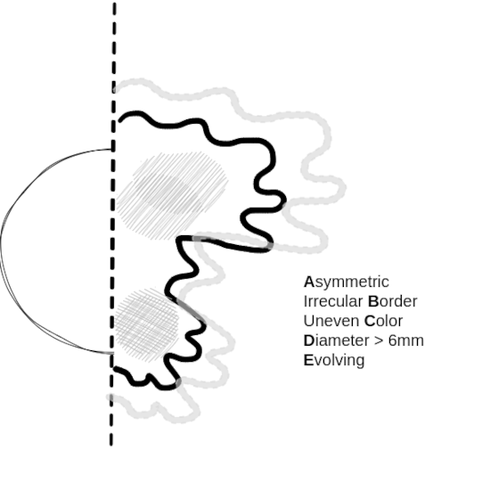

Occurs on areas of ⬆ sun exposure

Rx: Excission with 4mm margins.

Mohs micrographic surgery in high risk /  
cosmetically sensitive areas.

Poor prognosis  
if > 20mm wide or  
> 4mm deep

## Diabetic nephropathy

2. **Diffuse** mesangial sclerosis <- diffuse ⭐*increase of mesangial **cells** and **matrix***.
3. **Glomerular basement membrane thickening is the first to be seen**.
   1. ⭐ACEI OR ARB is recommended for BP control - Good evidence for slowing of progression of CKD
   2. Target ⭐HBA1C of **< 7** (subject to individual considerations)
4. ⭐Use **SGLT 2** inhibitors in *addition to above measures* in DM + DKD  
   2. ⭐**They decrease rate of progression of DKD** - CREDENCE trial  
   3. ⭐**They reduce cardiovascular risk**
5. ⭐*Spironolactone can be used because it **reduces albuminuria*** but risk of hyperkalemia.
- **SGLT2 inhibitors are not appropriate** for use in patients with *type 1 diabetes and kidney disease.*

Crigler - najjar : #autosomal-Recessive  
Type 2 #autosomalDominant , type 1 #autosomal-Recessive

### Gilbert syndrome

#autosomal-Recessive

- **phenobarbital** reduces bilirubin to normal levels in Crigler-najjar in Type II.

### Crigler-najjar

Type 1 - persistent neonatal jaundice. They usually **die of kernicterus.**  
Type 2 - neonatal but also at other stages of life.

- Defect in active excretion of conjugated bilirubin from the liver.
- **Liver appears black!**
- Except for **conjugated hyperbilirubinaemia**, liver enzymes are **normal!**.
- Patients are *asymptomatic*.
- Rotor syndrome was initially considered to be a variant of this but it's a different disease.
- Mnemonic: dubious -> shady -> black liver
- Symptomatically similar to Dubin-Johnson syndrome but the liver is **histologically normal**.
- KSS - kaerns sayre syndrome => CPEO at a young age (< 20) + pigmentary retinopathy.

[output not shown]

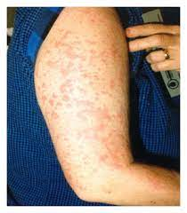

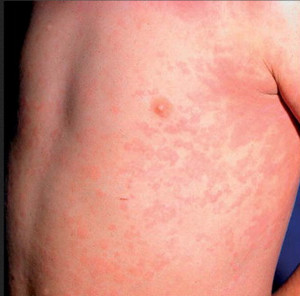

[figure not shown]

# Mechanisms of defence against intracellular pathogens

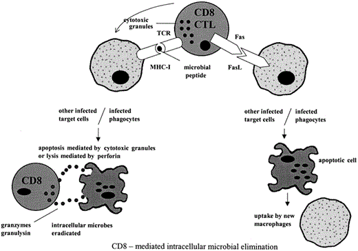

Cells involved in defence against intracellular pathogens:

- CD8 cytotoxic cells.
- Natural killer cells
- Antibodies play little to no role.
- CD4 helper cells 'help' by activating BOTH macrophages and CD8+ cells to do the killing.  
  Cytokines:
- Interferron gamma is vital in activating macrophages which have engulfed intracellular pathogens.

There are two types of HIV virus. ⭐**HIV-1 is more virulent and causes most of the HIV infections**, compared to HIV-2.[Source-Wiki](https://en.wikipedia.org/wiki/HIV)  
⭐**80-90% of all CD4 cells are killed due to infection within the first few weeks**. Patients are still undiagnosed at this point.

> Seroconversion can take a ⭐**few weeks to 3 months**, during which time you may or may not have symptoms.
- ⭐symmetrical **polyarthritis**  
  ART **quickly reduces viral load – by 90% in a few days**. Viral load should then become ⭐**undetectable within 1 to 3 months.**
> - Nat: 10 to 33 days (so even NAT has a window period of upto 1 month)
- ⭐**Antibody** test alone may not be sensitive enough **within 6 weeks** after exposure.  
  Symptoms in this phase commonly ⭐**involve the mucous membranes**:
- ⭐**oral hairy leukoplakia**  
  Sometimes, a ⭐CD4 count < 50 is called "**advanced HIV infection**"
- *IgG is passed to the foetus via the placenta* so ⭐**presence of foetal IgG does not confirm infection**.  
  Low pre-antiretroviral therapy (ART) CD4 counts are associated with poor immune recovery following ART initiation. So **early initiation of ART is crucial**.
- Effective ART results in sustained suppression of HIV RNA, improved cellular immunity (ie, CD4 count), and reduced HIV-immune activation (eg, proinflammatory cytokines, ⭐**chronic inflammation**, and T cell activation).
- Life expectancy on ART is ⭐**almost normal.**  
  There is a syndrome of peripheral fat loss with abdominal fat deposition associated with low HDL and high TGL and insulin resistance. This is called ⭐**antiretroviral associated lipodystrophy**

| Primary FSGS | Secondary FSGS |
| --- | --- |
| Sometimes responds to steroids, *failure of steroids is common*. Other immunosuppresants are used. | Usually poor response to steroids. ACEi are better |
| Presents as massive proteinuria, **haematuria** and hypertension. | Can be caused by any process which reduces functioning number of nephrons (eg. nephrectomy) |
|  | (nephrectomy, *hypertension*, gross obesity, IgA nephropathy, HIV, CMV, EBV, *hepatitis B and C*), (but !NOT DIABETES) |
|  | Lithium, Heroin, bisphosphonates (Pamidronate), anabolic steroids, |
|  | reflux nephropathy |
|  | Sickle cell disease [[Haematology MCQ discussion#Q5 Sickle cell disease]] |

- If we use electron microscopy, we see that the immune complexes are dome shaped ⭐**sub-*epi*thelial** deposits (aka "*humps*"). These are **CHARACTERISTIC** of **PSGN**. Subendothelial humps are also seen.
- **Renal biopsy** in PSGN shows diffuse, florid, acute inflammation in the glomerulus (*without necrosis* but occasionally with cellular *crescents*) with ⭐**neutrophils** and deposition of IgG and complement

> [!INFO] Inheritanc e of these syndromes  
> The only autosomal recessive one is spinal muscular atrophy.  
> Duchenne and Becker are X linked recessive.  
> Myotonic dystrophy - Autosomal dominant.

[output not shown]

> > ⭐ #autosomalDominant
> - ⭐**Begins in adulthood**
> - **Wasting of the temporalis and masseter muscles** contributes to a thin visage referred to as a **hatchet face**. Sternomastoid atrophy causes a *pencil necked* appearance. [Source](https://neurosigns.org/wiki/Myopathic_facies)
> - "often affects the ⭐*electrical conduction* system of the heart, *breathing and swallowing muscles*, bowels, lens of the eye (cataracts) and ⭐brain"
> - ⭐Other features:
>   1. Cataracts
>   2. Ptosis
>   3. Early balding
>   4. Subfertility
>   5. Diabetes
> - **Diagnosis**:
>   - Genetic testing is now first line.
>   - EMG was used before -> Motor nerve conduction studies (NCS) show decreased amplitude with normal latency and normal conduction velocities.

## Facioscapulohumeral muscular dystrophy

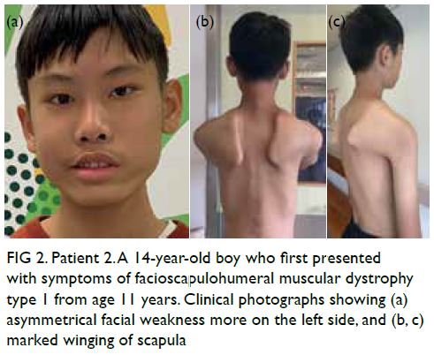

[figure not shown]

SPAINAL - Mahskular - ATROFEE

SMA inheritance : #autosomal-Recessive  
⭐ #autosomalDominant

- Onset in childhood, Patient is *weak* but **has muscle hypertrophy** (bulky muscles)

> [!INFO] CMT is a Slowly progressive peripheral ⭐motor + ⭐sensory neuropathy  
> **Features are very similar to Friedrich's ataxia** but **CMT has no cerebellar signs and CMT probably presents at an older age**.
- CMT-1: "Demyelinating" **Pain and temperature are usually not affected** because they are carried by *unmyelinated "C-Fibers".* Type 1 is #autosomalDominant inherited. CMT 1 is the commonest form.
  - An *unstable type of myelin* is formed and repeated myelination and demyelination lead to ⭐**thickened nerves.**
- **Lower limbs more involved** than upper limbs; *frequent tripping and sprained ankles*; *steppage gait* due to ⭐**foot drop**.

NK cells are lymphocytes but **do not express antigen specific receptors** like T or B cells.

- MHC class I molecules are downregulated by a cell a in response to **viral infections**, other infections and stress. (and loss of MHC class I prevents inhibition of the NK cell)
- *Activator receptor binding molecules are expressed on cells with DNA damage*, stress or infections.

Usually *not caused by genetic inheritance*: i.e sporadic.  
Normally, only the paternal copy of the prader-willi gene containing region of chromosome 15 is expressed. This is called paternal **imprinting**. This paternal expression can be lost due to deletion, maternal uniparental disomy, or imprinting defect. [Source](https://www.fpwr.org/what-is-prader-willi-syndrome#hereditary)

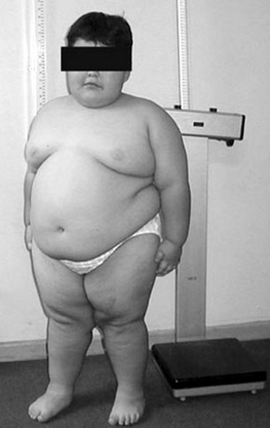

[figure not shown]

> [!INFO] Summary  
> Drugs to be started within 72 hours.  
> daily dosing to be continued for 28 days.  
> drugs used: The medication now used for PEP is a single tablet of **tenofovir disoproxil/emtricitabine (also known as Truvada) and two tablets of raltegravir**.

```
Prick injuries / Cuts / ⭐Mucous membrane *splashes* / Or non intact skin (injuries / dermatitis etc) with exposure to the following:
- (!but not saliva, urine) (Mnemonic: risk is only with fluid that's supposed to be inside the body)
    3. Technically, if the patient has been on *ART for the last 6 months* AND has *maintained undetectable viral load for the last 6 months*, ⭐**PEP is not needed**.
    4. Needle prick from a *dead body: PEP generally not recommended*.(case by case)
- For **unknown source** (needles in bins), PEP is generally not recommended as the overall risk is low. Case by case decisions is required.
+ if exposure occurs 'outside clinic hours' when rapid HIV cannot be done on the patients blood, '***Starter pack***' medication should be taken (ideally **within 2 hours**) after initial assessment by MO / microbiologist.
    + It consists of *3 antivirals to be taken over 5 days*. ((Tenofovir+Emtricitabine) Raltegravir/Efvavirnze/Dolutegravir))
+ HIV ELISA will be done in *6 and 12 weeks in the follow up*
```

> The risk for acquiring hepatitis B (**HBV**), hepatitis C (*HCV*), or human immunodeficiency (==HIV==) virus infections following an accidental needle stick are **30%,** *3%,* and ==0.3%,== respectively.

[output not shown]

[output not shown]

Standard error of the mean = the standard deviation of the sampling distribution of the sample means = "A measure of how different the population mean is from the sample mean".

Standard error = Standard deviation / Square root of the sample size.  
I.e higher the sample size, the lower the standard error.